# **Modelación de la física en el ambiente construido: Dinámica**

## **Movimiento en una dimensión**

### M. en C. Jonathan A. Urrutia Anguiano

### AR108B

### Simplificando en una sola dimensión

En esta sesión estudiaremos el caso de un objeto que se mueve en **línea recta**. Abordaremos los casos más sencillos primero:

- La velocidad es constante: **Movimiento rectilíneo uniforme (MRU)**
- La aceleración es constante: **Movimiento uniformemente acelerado (MUA)**

Finalmente, aprenderemos a **leer gráficas de posición vs. tiempo**, así como de velocidad y aceleración. Con éstas, seremos capaces de entender cualquier movimiento unidimensional.

## Movimiento Rectilíneo Uniforme (MRU)

En el caso unidimensional podemos considerar a la coordenada $x(t)$ como la que describe a una partícula que puede moverse a lo largo de una línea recta.

Si consideramos el caso en el que la **velocidad es constante**, entonces ésta es igual a la velocidad promedio, por lo que se puede despejar la posición de la siguiente manera:

$$ v = \frac{\Delta x(t)}{\Delta t} = \frac{x(t)-x_0}{t-t_0} \qquad\Longrightarrow\qquad x(t) = x_0 + v (t - t_0) $$

Lo que corresponde a la ecuaciónd e una recta con oordenda al origen $x_0$, pendiente $v$ y desplazada $t_0$ unidades a la derecha.

## Ejemplo:

Supongamos que, en primera aproximación, la línea 3 del Metro es una línea recta de 23 km de longitud entre las terminales Garibaldi y Constitución de 1927. Asumiento que los trenes no hacen paradas y dos de ellos salen al mismo tiempo de terminales opuestas, determina:

- En cuanto tiempo y en qué kilómetro se encuentran los trenes si el que sale de Garibaldi viaja a 60 km/hr y el otro a 80 km/hr.
- Si el tren que sale de Garibaldi lo hace a las 12:00 am, y el otro a las 12:12 ¿cómo se modifica la anterior respuesta?

[figure not shown]

[figure not shown]

[figure not shown]

## Movimiento Uniformemente Acelerado (MUA)

De nuevo considerando el caso unidimensional, podemos estudiar la dinámica del sistema en un caso sencillo.

Si consideramos el caso en el que la **aceleración es constante**, entonces ésta es igual a la aceleración promedio, por lo que se puede despejar la velocidad* de la siguiente manera:

$$ a = \frac{\Delta v(t)}{\Delta t} = \frac{v(t)-v_0}{t-t_0} \qquad\Longrightarrow\qquad v(t) = v_0 + a (t - t_0), $$

lo que corresponde a la ecuación de una recta con ordenda al origen $v_0$, pendiente $a$ y desplazada $t_0$ unidades a la derecha. En el caso de la posición tenemos

$$ x(t) = x_0 + v_0 (t-t_0) + \frac{1}{2} a (t - t_0)^2, $$

es decir, que el movimiento en este caso está descrito por una parábola.

## Ejemplos:

Se deja caer una pelota de masa $m$ a una velocidad desde el reposo.

[figure not shown]

## Ejemplo:

Se lanza una pelota hacia arriba con masa $m$ a una velocidad de $5$ m/s.

- ¿Cuánto tiempo tarda la pelota al suelo en llegar a la altura de la que fue lanzada?
- Si una segunda pelota se lanza sobre la misma linea, 0.5 segundos después de la primera con una velocidad de $4$ m/s ¿Encuanto tiempo y a qué altura se encuentran las pelota?

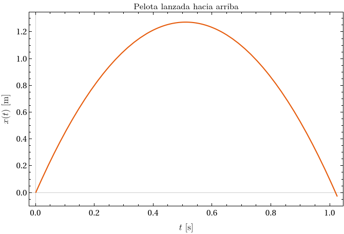

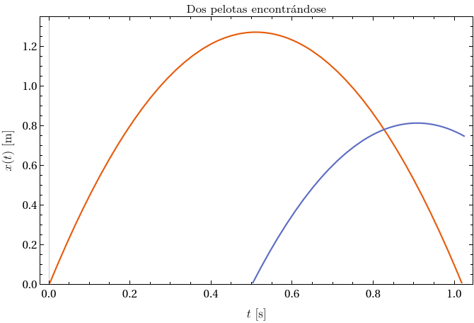

## Ejercicio

¿Cómo es el movimiento de una persona que sigue la gráfica de posición vs. tiempo mostrada a continuación? En equipo planteen diversas historias que correspondan a dichas gráficas.

[figure not shown]

Serway, Raymond A., y John W. Jewett Jr. "Física para ciencias e ingenierías Vol. 1". Cengage Learning Editores S.A. de C.V., 2008.